# LCLD

#### 2.1.3 离群点分析

```python
import pandas as pd
import matplotlib.pyplot as plt
%matplotlib inline
%pylab inline

loan_data = pd.read_csv('./lending-club-loan-data/lending-club-loan-data/loan_20160728.csv', header=0)
```

**思考：**

- 检测什么离群点？这个主要和业务相关。数据当中主要包含三方面信息：贷款者基本信息、贷款者信用信息、贷款者还款信息。
  - 在基本信息的属性当中，年收入（annual_inc）以及贷款者月债务总额除以月收入（dti）这两个属性或许是我们离群点分析的重点。
  - 在信用信息的属性当中，我们应当综合多个属性对其进行聚类分析，以找出信用方面的离群点。
  - 在还款信息的属性当中，或许我们应该高度关注还款状态的离群点。
- 离群点检测方法有很多种，那么你怎么选择呢？
  - 对于连续型属性，在没有类别划分的情况下可以使用z得分来判断离群点。
  - 对于可以划分类别的属性，可以使用聚类或分类算法来找出离群点。

*基本信息属性*

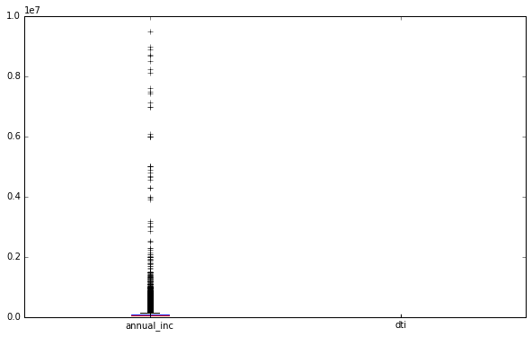

```python
outline_col = ['annual_inc', 'dti']
loan_data[outline_col].plot.box(figsize=(10, 6))
```

通过绘制这张图才发现，我们应该对数据进行归一化。在这里，我们使用**最小-最大规范化**。

```python
def min_max_uniform(target):
    loan_data[target+'_uniform'] = 0
    mean_target = loan_data[target].mean()
    max_target = loan_data[target].max()
    min_target = loan_data[target].min()
    loan_data[target+'_uniform'] = (loan_data[target] - min_target)/(max_target - min_target)
```

```python
min_max_uniform('annual_inc')
min_max_uniform('dti')
```

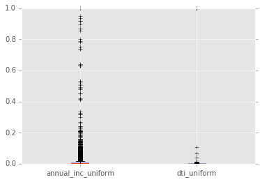

```python
import matplotlib
matplotlib.style.use('ggplot')

outline_col = ['annual_inc_uniform', 'dti_uniform']
loan_data[outline_col].plot.box()
```

[figure not shown]

```python
df = pd.DataFrame(np.random.rand(10, 5), columns=['A', 'B', 'C', 'D', 'E'])
df.plot.box()
```

值太多，箱型图看都看不清。

```python
def outlier_use_zscore(target, threshold):
    loan_data[target+'_is_outlier'] = False
    zscore = (loan_data[target] - loan_data[target].mean())/loan_data[target].std()
    loan_data[target+'_is_outlier'] = (zscore.abs() > threshold)
```

```python
outlier_use_zscore('annual_inc_uniform', 3)
outlier_use_zscore('dti_uniform', 3)
```

```python
loan_data.loc[loan_data.annual_inc_uniform_is_outlier == True, 'annual_inc'].describe()
```

```
count    7.083000e+03
mean     4.296183e+05
std      4.651652e+05
min      2.691560e+05
25%      3.000000e+05
50%      3.400000e+05
75%      4.250000e+05
max      9.500000e+06
Name: annual_inc, dtype: float64
```

**注意：这些年收入高的离谱啊，让人不敢相信，我需要调查一下。调查之后发现：哎，这些人都是开公司的（纯属猜测），卧槽。。。**

```python
loan_data.loc[loan_data.dti_uniform_is_outlier == True, ['dti', 'annual_inc', 'installment', 'loan_amnt', 'sub_grade_num']].describe()
```

|  | dti | annual_inc | installment | loan_amnt | sub_grade_num |
| --- | --- | --- | --- | --- | --- |
| count | 20.000000 | 20.000000 | 20.000000 | 20.000000 | 20.000000 |
| mean | 1179.093500 | 15466.890000 | 469.457500 | 16357.500000 | 19.750000 |
| std | 3026.994932 | 11436.869994 | 186.000605 | 7002.227559 | 4.470665 |
| min | 71.400000 | 0.000000 | 123.940000 | 3700.000000 | 12.000000 |
| 25% | 81.815000 | 7370.000000 | 347.587500 | 12000.000000 | 16.750000 |
| 50% | 102.045000 | 16702.000000 | 491.075000 | 15700.000000 | 20.000000 |
| 75% | 198.182500 | 20561.700000 | 598.965000 | 20000.000000 | 24.000000 |
| max | 9999.000000 | 38500.000000 | 741.680000 | 28000.000000 | 29.000000 |

```python
loan_data.loc[loan_data.dti > 100, ['dti', 'annual_inc', 'installment', 'loan_amnt', 'sub_grade_num']].head()
```

|  | dti | annual_inc | installment | loan_amnt | sub_grade_num |
| --- | --- | --- | --- | --- | --- |
| 475046 | 1092.52 | 1770.0 | 236.34 | 6550.0 | 20 |
| 476900 | 137.40 | 20000.0 | 531.44 | 15000.0 | 17 |
| 480179 | 136.97 | 17000.0 | 714.07 | 28000.0 | 21 |
| 484446 | 9999.00 | 0.0 | 712.96 | 20000.0 | 18 |
| 489021 | 100.09 | 27000.0 | 510.05 | 20000.0 | 21 |

**结论：这些贷款的朋友年收入这么低，债务又那么重，贷的款都抵得上一年的收入了。他们需要格外注意。从贷款评级（sub_grade_num）来看，LC确实对这群人看的很重，设定的风险值较高。**

**突然想到，在分析年收入离群点的时候，我们应该将个人贷款和商业贷款分开。之后再进行离群点分析。**

```python
purpose = loan_data.purpose.unique()
purpose.sort()
purpose
```

```
array(['car', 'credit_card', 'debt_consolidation', 'educational',
       'home_improvement', 'house', 'major_purchase', 'medical', 'moving',
       'other', 'renewable_energy', 'small_business', 'vacation', 'wedding'], dtype=object)
```

```python
title = loan_data.title.unique()
title.sort()
print title, len(title)
```

```
[nan '\tcredit_card' '\tdebt_consolidation' ..., '~Life Reorganization~'
 '~Summer Fun~'
 '\xc3\xae\xc2\x81\xc2\x97\xc3\xae\xc2\x81\xc2\x97MY FIRST CAR \xc3\xae\xc2\x81\xc2\x97\xc3\xae\xc2\x81\xc2\x97'] 63146
```

```python
loan_data.annual_inc.describe()
```

```
count    8.873790e+05
mean     7.502752e+04
std      6.469816e+04
min      0.000000e+00
25%      4.500000e+04
50%      6.500000e+04
75%      9.000000e+04
max      9.500000e+06
Name: annual_inc, dtype: float64
```

```python
loan_data.verification_status.unique()
```

```
array(['Verified', 'Source Verified', 'Not Verified'], dtype=object)
```

```python
len(loan_data.loc[loan_data.verification_status != 'Not Verified', 'verification_status'])
```

```
620629
```

```python
verified_loans = loan_data[loan_data.verification_status != 'Not Verified']
type(verified_loans)
```

```
pandas.core.frame.DataFrame
```

```python
from sklearn.cluster import KMeans

def classifier_using_kmeans(feas, clusters, desc_class):
    clf = KMeans(n_clusters=clusters)
    cls = clf.fit_predict(feas)
    loan_data[desc_class] = 0
    loan_data[desc_class] = cls

classifier_using_kmeans(loan_data['annual_inc'].reshape(-1, 1), 2, 'annual_inc_class')
```

```python
loan_data.loc[loan_data.annual_inc_class==0, 'annual_inc'].describe()
```

```
count    8.873440e+05
mean     7.478947e+04
std      5.116527e+04
min      0.000000e+00
25%      4.500000e+04
50%      6.500000e+04
75%      9.000000e+04
max      3.000000e+06
Name: annual_inc, dtype: float64
```

分类检测离群点：

```python
for i in range(len(loan_data.annual_inc_class.unique())):
    target = loan_data.loc[loan_data.annual_inc_class == i, 'annual_inc']
    zscore = (target - target.mean())/target.std()
    loan_data['annual_inc_is_outlier'] = (zscore.abs() > 3)
```

```python
loan_data['annual_inc_is_outlier'].sum()
```

```
0
```

```python
print loan_data.loc[loan_data.annual_inc_class==1, 'purpose'].unique()
print loan_data.loc[loan_data.annual_inc_class==0, 'purpose'].unique()
```

```
['home_improvement' 'debt_consolidation' 'credit_card' 'medical' 'other'
 'car']
['credit_card' 'car' 'small_business' 'other' 'wedding'
 'debt_consolidation' 'home_improvement' 'major_purchase' 'medical'
 'moving' 'vacation' 'house' 'renewable_energy' 'educational']
```

**结论：看来穷人贷款用途多种多样啊**

*信用信息属性*

对于信用信息的离群点检测，我们缺失一个计算公式：通过信用属性来计算信用得分。

*贷款信息属性*

思考良久，我发现，贷款的贷款状态并不是离群点所需要去解决的问题，而是在后续统计当中应该发现的问题。

### 3. 统计分析

那么在此你想分析什么呢？让我们来想想：

- 基本信息统计：
  - 不同收入等级的贷款者贷款用途有何不同？
  - 不同收入等级的贷款者贷款量如何？
  - 贷款者年收入、工作年限、住房状态有何特征？
  - 美国哪个州贷款人数最多？哪个贷款额度最高？增长率如何？
- 贷款信息统计：
  - 有哪些类型的贷款更容易吸引投资者投资？
  - 什么样的贷款者喜欢36个月分期付款？60个月的呢？
  - 贷款等级不同的贷款者，他们的信用信息有何不同？
  - 贷款状态不同的贷款，有哪些可以分析的呢？
    - 违约的贷款者有什么特征？
    - 各种状态下的贷款额度有何特点？（来自网络https://www.kaggle.com/erykwalczak/d/wendykan/lending-club-loan-data/initial-loan-book-analysis/discussion）
  - 贷款用途最多的是哪一种？最少的呢？
  - 投资回报率最高的贷款具有什么特征？

### 3.1 不同收入等级的贷款者贷款用途有何不同？

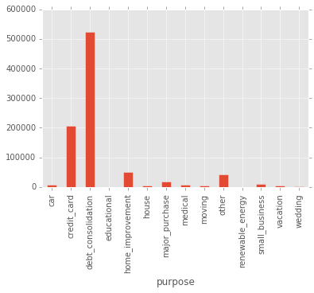

```python
loan_data.loc[loan_data.annual_inc_class == 0, ['purpose', 'id']].groupby('purpose').id.agg(np.count_nonzero).plot(kind='bar')
```

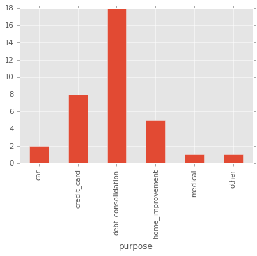

```python
loan_data.loc[loan_data.annual_inc_class == 1, ['purpose', 'id']].groupby('purpose').id.agg(np.count_nonzero).plot(kind='bar')
```

**结论：从上述两个图当中可以看出，虽然贷款者收入相差很大，但贷款用途基本一致，贷款用途排名前三的都是debt_consolidation、credit_card以及home_improvement。**

### 3.2 不同收入等级的贷款者贷款量如何？

```python
for i in range(len(loan_data.annual_inc_class.unique())):
    fai = loan_data.loc[loan_data.annual_inc_class == i, 'funded_amnt_inv']
    print '%d: %.0f %d %.3f' % (i, fai.sum(), fai.count(), fai.mean())
```

```
0: 13046112162 887344 14702.429
1: 545980 35 15599.429
```

**结论：从上述结果看来，高收入人群虽然收入高，贷款量少，但人均贷款和低收入人群相差不大。这应该和LC限制最高贷款额度的政策有关**

### 3.3 贷款者年收入、工作年限、住房状态有何特征？

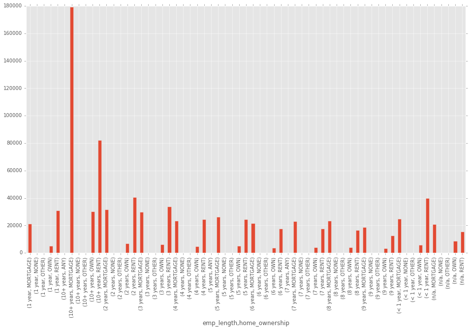

```python
loan_data.loc[loan_data.annual_inc_class == 0, ['emp_length', 'home_ownership', 'id']].groupby(['emp_length', 'home_ownership']).id.agg(np.count_nonzero).plot(kind='bar', figsize=(16, 9))
```

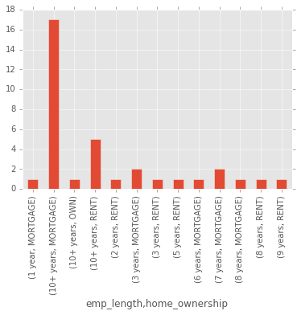

```python
loan_data.loc[loan_data.annual_inc_class == 1, ['emp_length', 'home_ownership', 'id']].groupby(['emp_length', 'home_ownership']).id.agg(np.count_nonzero).plot(kind='bar')
```

**结论：从以上两个图当中可以看出，年收入水平在（0～300万）以及在（300万～950万）的贷款者中，贷款量最多的都是拥有10年以上工龄，且房屋状态为抵押贷款的人群。但是低收入者和高收入者的贷款量相差悬殊。高收入水平的贷款者数量不超过50，对于贷款总数887379来说几乎可以忽略不计。**